# Tilat

## Tarkastelu palasina

Luen aineiston, jossa olen korvannut puuttuvat havainnot mediaanilla. Se keskiarvoistaa aineistoa, mutta puuttuvia on niin paljon, etta ajattelin kokeilla kuitenkin nain.

```r
# load data
setwd("~/GitHub/tilataso")
library(readr)
tilat<-read.csv(file="tilailman.csv", header=TRUE)
```

### 1-20 muuttujaa

```r
colnames(tilat)
```

```
##   [1] "Alkup_jarj"
##   [2] "Kayntikk"
##   [3] "Haastrooli_1OmEiosall_2OmOsall_3Esimies"
##   [4] "Tila"
##   [5] "Tuotsuunta"
##   [6] "Emakot"
##   [7] "Ensikot"
##   [8] "Lihasiat_tontilla"
##   [9] "Karjut_astsiem"
##  [10] "Karjut_haju"
##  [11] "Tautsu"
##  [12] "Tautsuok"
##  [13] "Tautsu_012"
##  [14] "Siilotkat"
##  [15] "Tuhoei"
```

[output cut: 359 more lines]

```r
colnames(tilat)[ apply(tilat, 2, anyNA) ]
```

```
## [1] "VAR00003"           "TII_alusta_5_laatu" "TII_lelukomm"
## [4] "POR_pr_viemar"      "VAR00001"
```

```r
tilat<-tilat[ , apply(tilat, 2, function(x) !any(is.na(x)))]
```

Sitten valitsen ensimmaiset sarakkeet tarkasteltavaksi ja piirran ne alustavasti.

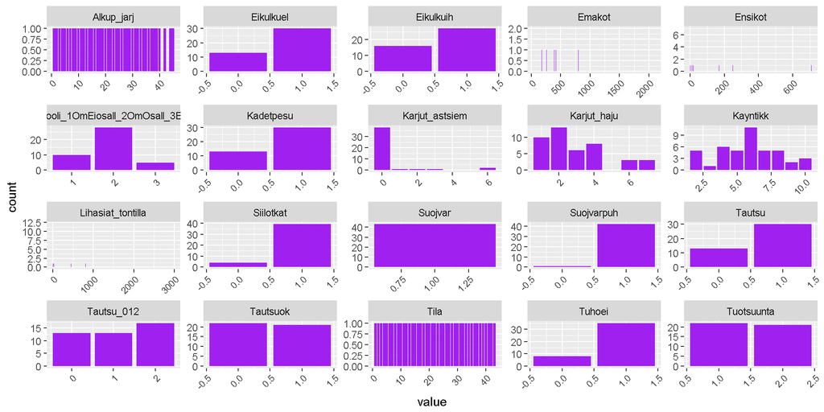

```r
kuvat1<-tilat[,1:20]
gather(kuvat1) %>% ggplot(aes(value)) + facet_wrap("key", scales = "free") + geom_bar(fill="purple" ) + theme(axis.text.x = element_text(angle = 45, hjust = 1, size = 8))+   scale_fill_manual("key")
```

ja

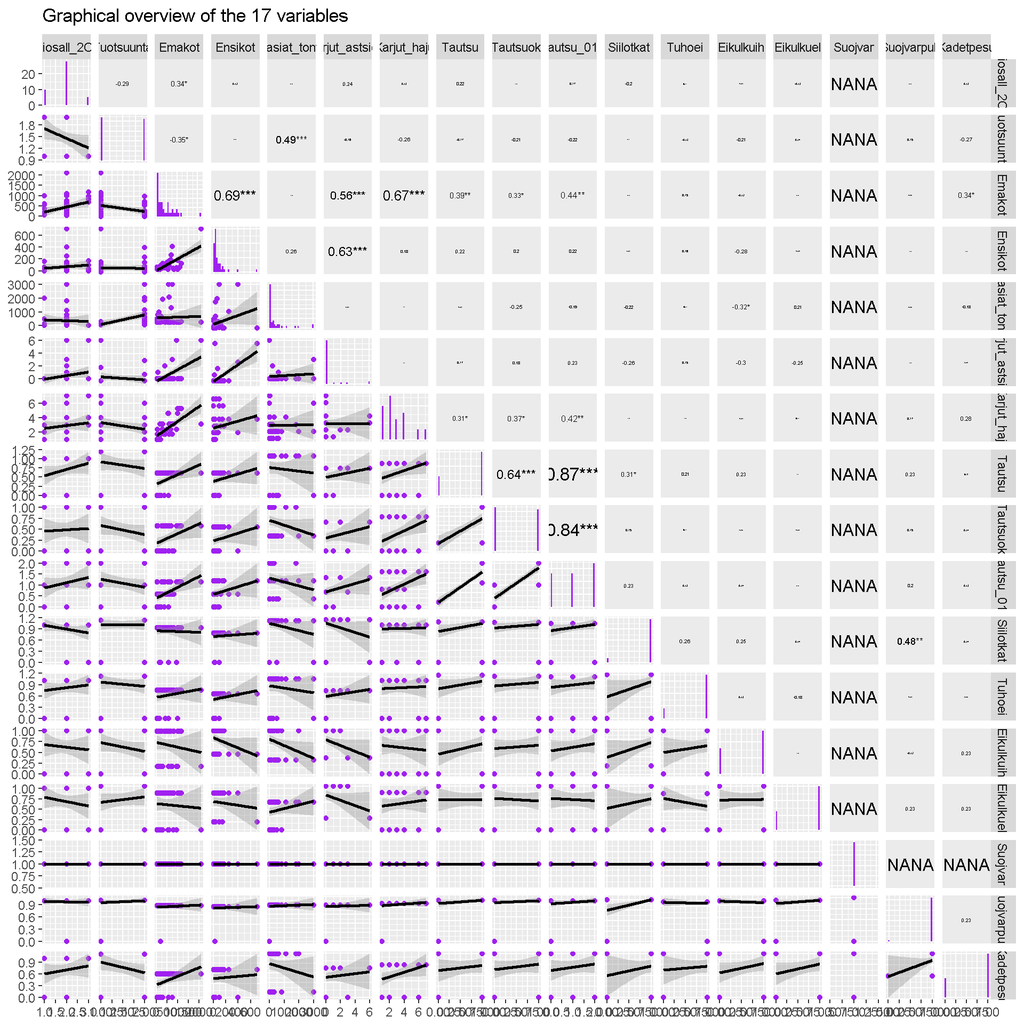

```r
kor1<-kuvat1[-1]
kor1<-kor1[-1]
kor1<-kor1[-2]

cor_fun <- function(data, mapping, method="pearson", ndp=2, sz=5, stars=TRUE, ...){

    data <- na.omit(data[,c(as.character(mapping$x), as.character(mapping$y))])

    x <- data[,as.character(mapping$x)]
    y <- data[,as.character(mapping$y)]

    corr <- cor.test(x, y, method=method)
    est <- corr$estimate
    lb.size <- sz* abs(est)

    if(stars){
      stars <- c("***", "**", "*", "")[findInterval(corr$p.value, c(0, 0.001, 0.01, 0.05, 1))]
      lbl <- paste0(round(est, ndp), stars)
    }else{
      lbl <- round(est, ndp)
    }

    ggplot(data=data, mapping=mapping) +
      annotate("text", x=mean(x), y=mean(y), label=lbl, size=lb.size,...)+
      theme(panel.grid = element_blank())
  }


ggpairs(kor1%>%mutate_all(as.numeric),
        lower=list(continuous=wrap("smooth", colour="purple")),
        diag=list(continuous=wrap("barDiag", fill="purple")),
        upper=list(continuous=cor_fun),title="Graphical overview of the 17 variables")
```

Sitten tarkastelen muuttujien nimia ja luonnetta (jatkuva/kategorinen).

```r
colnames(kuvat1)
```

```
##  [1] "Alkup_jarj"
##  [2] "Kayntikk"
##  [3] "Haastrooli_1OmEiosall_2OmOsall_3Esimies"
##  [4] "Tila"
##  [5] "Tuotsuunta"
##  [6] "Emakot"
##  [7] "Ensikot"
##  [8] "Lihasiat_tontilla"
##  [9] "Karjut_astsiem"
## [10] "Karjut_haju"
## [11] "Tautsu"
## [12] "Tautsuok"
## [13] "Tautsu_012"
## [14] "Siilotkat"
## [15] "Tuhoei"
## [16] "Eikulkuih"
## [17] "Eikulkuel"
## [18] "Suojvar"
## [19] "Suojvarpuh"
## [20] "Kadetpesu"
```

```r
#Pidetaan nama
keeps1<-
c(

"Haastrooli_1OmEiosall_2OmOsall_3Esimies"
,"Tila"
,"Tuotsuunta"
,"Emakot"
,"Ensikot"
,"Lihasiat_tontilla"

,"Karjut_haju"
,"Tautsu"
,"Tautsuok"
,"Tautsu_012"
,"Siilotkat"
,"Tuhoei"
,"Eikulkuih"
,"Eikulkuel"

,"Suojvarpuh"
,"Kadetpesu"
,"EMKUOL")

#Jatkuvia nama
num1<-c("Emakot"
,"Ensikot"
,"Lihasiat_tontilla"
,"Karjut_haju")


#kuvat1n<-kuvat1 %>%
#  select(num1)

#kuvat1<-kuvat1%>%
#  select(keeps1)

#Tama on kategoristen setti
kuvat11<- kuvat1 %>% dplyr::select(one_of(keeps1))%>%  dplyr::select(-one_of(num1))

#ja kategoriset muuttujat
kat1<-colnames(kuvat11)

#lisataan viela kuolleisuusjako
#kuvat1$EMKUOL<-tilat$EMKUOLLJAKO
#kuvat11<-drop(kuvat1,one_of(num1)
#%>%
#  rename(developer = assignee.login) %>%
#  select(-starts_with("assignee"), -title, -comments, -locked, #-labels, -id, -body) %>%
#  count(developer)
```

Paatan tiputtaa tassa kohtaa muutaman muuttujan. Lisaan aineistoon emkuoljako-muuttujan ja teen taulukon

```r
df1<- dplyr::select(kuvat1, one_of(keeps1))
df1<-df1[-2]
df1a<-df1
df1a$EMKUOL<-tilat$EMKUOLLJAKO
head(df1a)
```

```
##   Haastrooli_1OmEiosall_2OmOsall_3Esimies Tuotsuunta Emakot Ensikot
## 1                                       2          1    600     150
## 2                                       2          2     37      38
## 3                                       2          2    300     100
## 4                                       1          1    550       0
## 5                                       2          1   2100     710
## 6                                       1          2     60      30
##   Lihasiat_tontilla Karjut_haju Tautsu Tautsuok Tautsu_012 Siilotkat
## 1                 0           4      1        1          2         1
## 2               250           1      0        0          0         1
## 3               300           4      1        1          2         1
## 4                 0           6      1        1          2         1
## 5                 0           4      1        1          2         1
## 6               130           2      1        1          2         1
##   Tuhoei Eikulkuih Eikulkuel Suojvarpuh Kadetpesu EMKUOL
## 1      1         1         0          1         1      0
## 2      0         1         1          1         1      0
## 3      1         0         0          1         0      0
## 4      1         1         0          1         1      1
## 5      1         0         0          1         1      1
## 6      0         0         1          1         0      0
```

```r
CreateTableOne(vars=keeps1,strata=c("EMKUOL"),factorVars=kat1,data=df1a )
```

```
##                                              Stratified by EMKUOL
##                                               0
##   n                                               23
##   Haastrooli_1OmEiosall_2OmOsall_3Esimies (%)
##      1                                             4 ( 17.4)
##      2                                            17 ( 73.9)
##      3                                             2 (  8.7)
##   Tuotsuunta = 2 (%)                              14 ( 60.9)
##   Emakot (mean (sd))                          305.26 (291.79)
##   Ensikot (mean (sd))                          41.52 (45.16)
##   Lihasiat_tontilla (mean (sd))               406.13 (718.12)
##   Karjut_haju (mean (sd))                       2.43 (1.59)
##   Tautsu = 1 (%)                                  15 ( 65.2)
##   Tautsuok = 1 (%)                                 9 ( 39.1)
##   Tautsu_012 (%)
##      0                                             8 ( 34.8)
##      1                                             7 ( 30.4)
##      2                                             8 ( 34.8)
##   Siilotkat = 1 (%)                               21 ( 91.3)
##   Tuhoei = 1 (%)                                  16 ( 69.6)
##   Eikulkuih = 1 (%)                               16 ( 69.6)
##   Eikulkuel = 1 (%)                               14 ( 60.9)
##   Suojvarpuh = 1 (%)                              23 (100.0)
##   Kadetpesu = 1 (%)                               14 ( 60.9)
##   EMKUOL (mean (sd))                            0.00 (0.00)
##                                              Stratified by EMKUOL
##                                               1               p      test
##   n                                               20
##   Haastrooli_1OmEiosall_2OmOsall_3Esimies (%)                  0.431
##      1                                             6 (30.0)
##      2                                            11 (55.0)
##      3                                             3 (15.0)
##   Tuotsuunta = 2 (%)                               7 (35.0)    0.165
##   Emakot (mean (sd))                          570.95 (509.87)  0.039
##   Ensikot (mean (sd))                         104.75 (174.17)  0.101
##   Lihasiat_tontilla (mean (sd))               353.20 (773.30)  0.817
##   Karjut_haju (mean (sd))                       3.45 (1.90)    0.064
##   Tautsu = 1 (%)                                  15 (75.0)    0.716
##   Tautsuok = 1 (%)                                12 (60.0)    0.289
##   Tautsu_012 (%)                                               0.733
##      0                                             5 (25.0)
##      1                                             6 (30.0)
##      2                                             9 (45.0)
##   Siilotkat = 1 (%)                               18 (90.0)    1.000
##   Tuhoei = 1 (%)                                  19 (95.0)    0.081
##   Eikulkuih = 1 (%)                               11 (55.0)    0.503
##   Eikulkuel = 1 (%)                               16 (80.0)    0.303
##   Suojvarpuh = 1 (%)                              19 (95.0)    0.944
##   Kadetpesu = 1 (%)                               16 (80.0)    0.303
##   EMKUOL (mean (sd))                            1.00 (0.00)   <0.001
```

### Muuttujat 21-40

Seuraavat muuttujat ja niiden tarkastelu

```r
kuvat2<-tilat[,21:40]
colnames(kuvat2)
```

```
##  [1] "Toimsiis"
##  [2] "Saappesu"
##  [3] "Lasthu"
##  [4] "Teurkuski_0paaseesikalaan_1eipaase"
##  [5] "JOU_kertayt_0ei"
##  [6] "JOU_tuotvaiherill_0ei"
##  [7] "JOU_pesu_0ei"
##  [8] "JOU_pesuaine_0ei"
##  [9] "JOU_desinf_liu_0ei_1liuos_2kuiva"
## [10] "JOU_tyhjana_mi1vrk_0ei"
## [11] "PORSOSASTO_kertayt_0ei"
## [12] "PORS_tuotvaiherill_0ei"
## [13] "PORS_pesu_0ei"
## [14] "PORS_pesuaine_0ei"
## [15] "PORS_desinf_0ei_1LIU_2KUIVA"
## [16] "PORS_tyhjana_mi1vr_0ei"
## [17] "Raa_0ei_1kontti_2huone"
## [18] "Raa_auto_hakee_0ei"
## [19] "Raa_viilea_0ei"
## [20] "Raa_tuhoelain_1eipaase_0paaseesic"
```

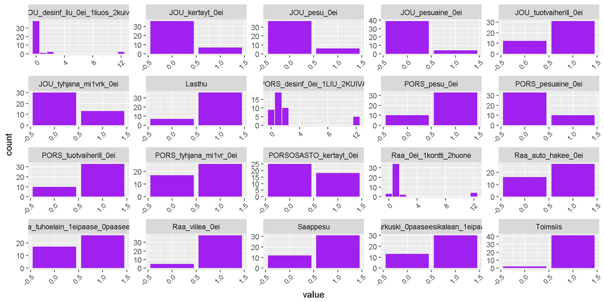

```r
gather(kuvat2) %>% ggplot(aes(value)) + facet_wrap("key", scales = "free") + geom_bar(fill="purple") + theme(axis.text.x = element_text(angle = 45, hjust = 1, size = 8))+   scale_fill_manual("key")
```

ja

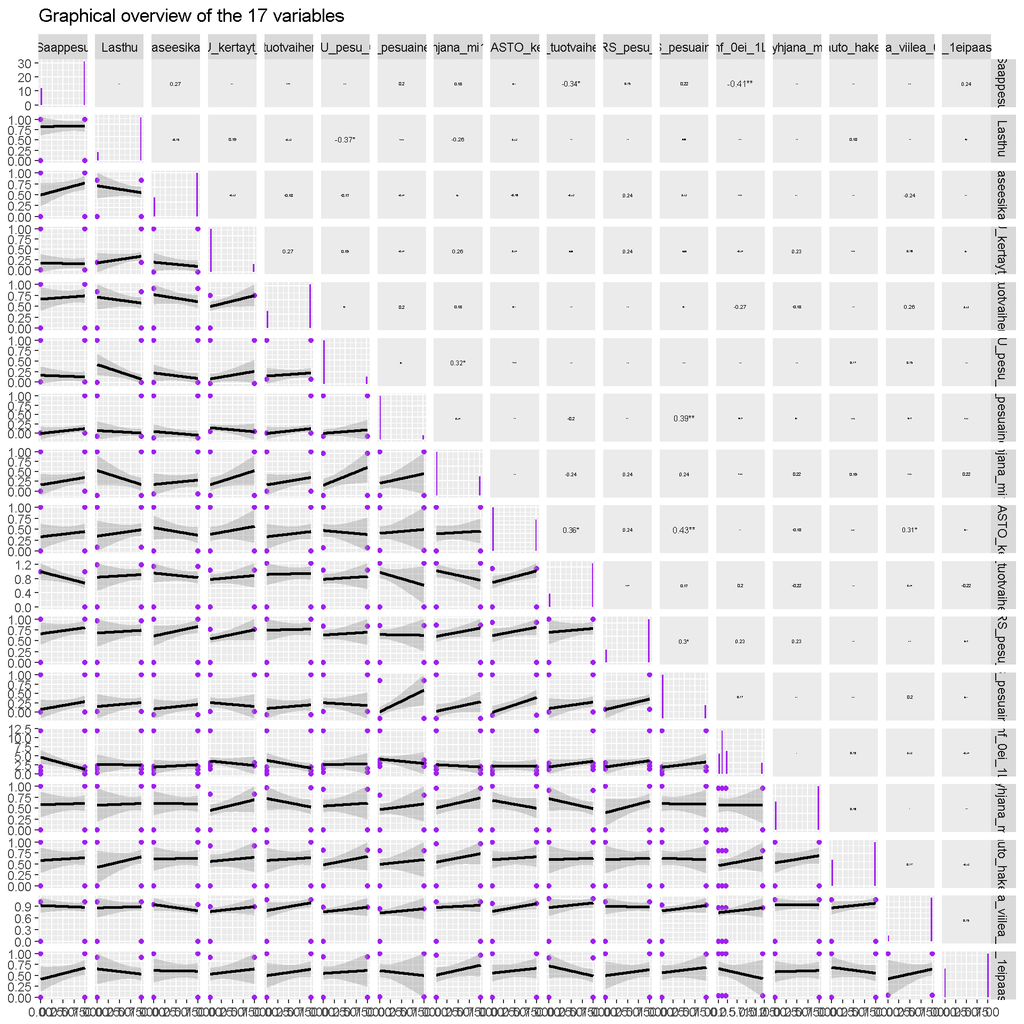

```r
kor2<-kuvat2[-1]
kor2<-kor2[-16]
kor2<-kor2[-8]

cor_fun <- function(data, mapping, method="pearson", ndp=2, sz=5, stars=TRUE, ...){

    data <- na.omit(data[,c(as.character(mapping$x), as.character(mapping$y))])

    x <- data[,as.character(mapping$x)]
    y <- data[,as.character(mapping$y)]

    corr <- cor.test(x, y, method=method)
    est <- corr$estimate
    lb.size <- sz* abs(est)

    if(stars){
      stars <- c("***", "**", "*", "")[findInterval(corr$p.value, c(0, 0.001, 0.01, 0.05, 1))]
      lbl <- paste0(round(est, ndp), stars)
    }else{
      lbl <- round(est, ndp)
    }

    ggplot(data=data, mapping=mapping) +
      annotate("text", x=mean(x), y=mean(y), label=lbl, size=lb.size,...)+
      theme(panel.grid = element_blank())
  }


ggpairs(kor2%>%mutate_all(as.numeric),
        lower=list(continuous=wrap("smooth", colour="purple")),
        diag=list(continuous=wrap("barDiag", fill="purple")),
        upper=list(continuous=cor_fun),title="Graphical overview of the 17 variables")
```

Sitten tarkastelen muuttujien nimia ja luonnetta (jatkuva/kategorinen).

```r
colnames(kuvat2)
```

```
##  [1] "Toimsiis"
##  [2] "Saappesu"
##  [3] "Lasthu"
##  [4] "Teurkuski_0paaseesikalaan_1eipaase"
##  [5] "JOU_kertayt_0ei"
##  [6] "JOU_tuotvaiherill_0ei"
##  [7] "JOU_pesu_0ei"
##  [8] "JOU_pesuaine_0ei"
##  [9] "JOU_desinf_liu_0ei_1liuos_2kuiva"
## [10] "JOU_tyhjana_mi1vrk_0ei"
## [11] "PORSOSASTO_kertayt_0ei"
## [12] "PORS_tuotvaiherill_0ei"
## [13] "PORS_pesu_0ei"
## [14] "PORS_pesuaine_0ei"
## [15] "PORS_desinf_0ei_1LIU_2KUIVA"
## [16] "PORS_tyhjana_mi1vr_0ei"
## [17] "Raa_0ei_1kontti_2huone"
## [18] "Raa_auto_hakee_0ei"
## [19] "Raa_viilea_0ei"
## [20] "Raa_tuhoelain_1eipaase_0paaseesic"
```

```r
summary(kuvat2)
```

```
##     Toimsiis         Saappesu          Lasthu
##  Min.   :0.0000   Min.   :0.0000   Min.   :0.0000
##  1st Qu.:1.0000   1st Qu.:0.0000   1st Qu.:1.0000
##  Median :1.0000   Median :1.0000   Median :1.0000
##  Mean   :0.9535   Mean   :0.7209   Mean   :0.8372
##  3rd Qu.:1.0000   3rd Qu.:1.0000   3rd Qu.:1.0000
##  Max.   :1.0000   Max.   :1.0000   Max.   :1.0000
##  Teurkuski_0paaseesikalaan_1eipaase JOU_kertayt_0ei  JOU_tuotvaiherill_0ei
##  Min.   :0.0000                     Min.   :0.0000   Min.   :0.0000
##  1st Qu.:0.0000                     1st Qu.:0.0000   1st Qu.:0.0000
##  Median :1.0000                     Median :0.0000   Median :1.0000
##  Mean   :0.6977                     Mean   :0.1628   Mean   :0.7209
##  3rd Qu.:1.0000                     3rd Qu.:0.0000   3rd Qu.:1.0000
##  Max.   :1.0000                     Max.   :1.0000   Max.   :1.0000
##   JOU_pesu_0ei    JOU_pesuaine_0ei  JOU_desinf_liu_0ei_1liuos_2kuiva
##  Min.   :0.0000   Min.   :0.00000   Min.   : 0.0000
##  1st Qu.:0.0000   1st Qu.:0.00000   1st Qu.: 0.0000
##  Median :0.0000   Median :0.00000   Median : 0.0000
##  Mean   :0.1395   Mean   :0.09302   Mean   : 0.6744
##  3rd Qu.:0.0000   3rd Qu.:0.00000   3rd Qu.: 0.0000
##  Max.   :1.0000   Max.   :1.00000   Max.   :12.0000
##  JOU_tyhjana_mi1vrk_0ei PORSOSASTO_kertayt_0ei PORS_tuotvaiherill_0ei
##  Min.   :0.0000         Min.   :0.0000         Min.   :0.0000
##  1st Qu.:0.0000         1st Qu.:0.0000         1st Qu.:1.0000
##  Median :0.0000         Median :0.0000         Median :1.0000
##  Mean   :0.3023         Mean   :0.4186         Mean   :0.7674
##  3rd Qu.:1.0000         3rd Qu.:1.0000         3rd Qu.:1.0000
##  Max.   :1.0000         Max.   :1.0000         Max.   :1.0000
##  PORS_pesu_0ei    PORS_pesuaine_0ei PORS_desinf_0ei_1LIU_2KUIVA
##  Min.   :0.0000   Min.   :0.0000    Min.   : 0.000
##  1st Qu.:1.0000   1st Qu.:0.0000    1st Qu.: 1.000
##  Median :1.0000   Median :0.0000    Median : 1.000
##  Mean   :0.7674   Mean   :0.2326    Mean   : 2.302
##  3rd Qu.:1.0000   3rd Qu.:0.0000    3rd Qu.: 2.000
##  Max.   :1.0000   Max.   :1.0000    Max.   :12.000
##  PORS_tyhjana_mi1vr_0ei Raa_0ei_1kontti_2huone Raa_auto_hakee_0ei
##  Min.   :0.0000         Min.   : 0             Min.   :0.0000
##  1st Qu.:0.0000         1st Qu.: 1             1st Qu.:0.0000
##  Median :1.0000         Median : 1             Median :1.0000
##  Mean   :0.6047         Mean   : 2             Mean   :0.6279
##  3rd Qu.:1.0000         3rd Qu.: 1             3rd Qu.:1.0000
##  Max.   :1.0000         Max.   :12             Max.   :1.0000
##  Raa_viilea_0ei   Raa_tuhoelain_1eipaase_0paaseesic
##  Min.   :0.0000   Min.   :0.0000
##  1st Qu.:1.0000   1st Qu.:0.0000
##  Median :1.0000   Median :1.0000
##  Mean   :0.8837   Mean   :0.6047
##  3rd Qu.:1.0000   3rd Qu.:1.0000
##  Max.   :1.0000   Max.   :1.0000
```

```r
#Pidetaan nama
keeps2<-
c(
 "Saappesu"
 ,"Lasthu"
 ,"Teurkuski_0paaseesikalaan_1eipaase"
 ,"JOU_kertayt_0ei"
 ,"JOU_tuotvaiherill_0ei"
 ,"JOU_pesu_0ei"
 ,"JOU_pesuaine_0ei"
 ,  "JOU_tyhjana_mi1vrk_0ei"
 ,"PORSOSASTO_kertayt_0ei"
, "PORS_tuotvaiherill_0ei"
,"PORS_pesu_0ei"
,"PORS_pesuaine_0ei"
,"PORS_tyhjana_mi1vr_0ei"
,"Raa_auto_hakee_0ei"
,"Raa_tuhoelain_1eipaase_0paaseesic")

#Jatkuvia nama



#kuvat1n<-kuvat1 %>%
#  select(num1)

#kuvat1<-kuvat1%>%
#  select(keeps1)

#Tama on kategoristen setti
#kuvat11<- kuvat1 %>% dplyr::select(one_of(keeps1))%>%  dplyr::select(-one_of(num1))

#ja kategoriset muuttujat
kat2<-keeps2

#lisataan viela kuolleisuusjako
#kuvat1$EMKUOL<-tilat$EMKUOLLJAKO
#kuvat11<-drop(kuvat1,one_of(num1)
#%>%
#  rename(developer = assignee.login) %>%
#  select(-starts_with("assignee"), -title, -comments, -locked, #-labels, -id, -body) %>%
#  count(developer)
```

Paatan tiputtaa tassa kohtaa muutaman muuttujan. Lisaan aineistoon emkuoljako-muuttujan ja teen taulukon

```r
df2<- dplyr::select(kuvat2, one_of(keeps2))
df2a<-df2
df2a$EMKUOL<-tilat$EMKUOLLJAKO


CreateTableOne(vars=keeps2,strata=c("EMKUOL"),factorVars=kat2,data=df2a)
```

```
##                                             Stratified by EMKUOL
##                                              0          1          p
##   n                                          23         20
##   Saappesu = 1 (%)                           14 (60.9)  17 (85.0)   0.156
##   Lasthu = 1 (%)                             19 (82.6)  17 (85.0)   1.000
##   Teurkuski_0paaseesikalaan_1eipaase = 1 (%) 17 (73.9)  13 (65.0)   0.763
##   JOU_kertayt_0ei = 1 (%)                     3 (13.0)   4 (20.0)   0.840
##   JOU_tuotvaiherill_0ei = 1 (%)              16 (69.6)  15 (75.0)   0.956
##   JOU_pesu_0ei = 1 (%)                        4 (17.4)   2 (10.0)   0.798
##   JOU_pesuaine_0ei = 1 (%)                    2 ( 8.7)   2 (10.0)   1.000
##   JOU_tyhjana_mi1vrk_0ei = 1 (%)              5 (21.7)   8 (40.0)   0.333
##   PORSOSASTO_kertayt_0ei = 1 (%)              9 (39.1)   9 (45.0)   0.937
##   PORS_tuotvaiherill_0ei = 1 (%)             19 (82.6)  14 (70.0)   0.539
##   PORS_pesu_0ei = 1 (%)                      17 (73.9)  16 (80.0)   0.913
##   PORS_pesuaine_0ei = 1 (%)                   4 (17.4)   6 (30.0)   0.539
##   PORS_tyhjana_mi1vr_0ei = 1 (%)             13 (56.5)  13 (65.0)   0.799
##   Raa_auto_hakee_0ei = 1 (%)                 16 (69.6)  11 (55.0)   0.503
##   Raa_tuhoelain_1eipaase_0paaseesic = 1 (%)  13 (56.5)  13 (65.0)   0.799
##                                             Stratified by EMKUOL
##                                              test
##   n
##   Saappesu = 1 (%)
##   Lasthu = 1 (%)
##   Teurkuski_0paaseesikalaan_1eipaase = 1 (%)
##   JOU_kertayt_0ei = 1 (%)
##   JOU_tuotvaiherill_0ei = 1 (%)
##   JOU_pesu_0ei = 1 (%)
##   JOU_pesuaine_0ei = 1 (%)
##   JOU_tyhjana_mi1vrk_0ei = 1 (%)
##   PORSOSASTO_kertayt_0ei = 1 (%)
##   PORS_tuotvaiherill_0ei = 1 (%)
##   PORS_pesu_0ei = 1 (%)
##   PORS_pesuaine_0ei = 1 (%)
##   PORS_tyhjana_mi1vr_0ei = 1 (%)
##   Raa_auto_hakee_0ei = 1 (%)
##   Raa_tuhoelain_1eipaase_0paaseesic = 1 (%)
```

### Seuraavat muuttujat

```r
kuvat3<-tilat[,41:60]
colnames(kuvat3)
```

```
##  [1] "Tuhoeltorjun_0ei_1ki_2ko_3myr_4pyy_5ammatt_6muu"
##  [2] "Tuhoelmerkkeja_0kylla_1ei"
##  [3] "Lintuja_0kylla_1ei"
##  [4] "Tuho_ohjelma"
##  [5] "Kissoja"
##  [6] "kissoja0on1ei"
##  [7] "Kotielain_sikalaan_0kylla_1ei"
##  [8] "Vesi_1kunn_0oma"
##  [9] "Ery"
## [10] "Parvo"
## [11] "Koli"
## [12] "Sirko"
## [13] "ClC"
## [14] "ClA"
## [15] "SI"
## [16] "APP"
## [17] "Loish_krt_vuosi"
## [18] "Loisaika_1ennenpors_2_porskars"
## [19] "Uusiryh"
## [20] "Em_hakissa_yhdjal_0maxtunteja_1vrkjne"
```

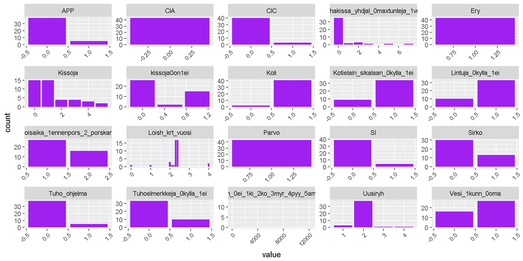

```r
gather(kuvat3) %>% ggplot(aes(value)) + facet_wrap("key", scales = "free") + geom_bar(fill="purple") + theme(axis.text.x = element_text(angle = 45, hjust = 1, size = 8))+   scale_fill_manual("key")
```

Sitten tarkastelen muuttujien nimia ja luonnetta (jatkuva/kategorinen).

```r
colnames(kuvat3)
```

```
##  [1] "Tuhoeltorjun_0ei_1ki_2ko_3myr_4pyy_5ammatt_6muu"
##  [2] "Tuhoelmerkkeja_0kylla_1ei"
##  [3] "Lintuja_0kylla_1ei"
##  [4] "Tuho_ohjelma"
##  [5] "Kissoja"
##  [6] "kissoja0on1ei"
##  [7] "Kotielain_sikalaan_0kylla_1ei"
##  [8] "Vesi_1kunn_0oma"
##  [9] "Ery"
## [10] "Parvo"
## [11] "Koli"
## [12] "Sirko"
## [13] "ClC"
## [14] "ClA"
## [15] "SI"
## [16] "APP"
## [17] "Loish_krt_vuosi"
## [18] "Loisaika_1ennenpors_2_porskars"
## [19] "Uusiryh"
## [20] "Em_hakissa_yhdjal_0maxtunteja_1vrkjne"
```

```r
summary(kuvat3)
```

```
##  Tuhoeltorjun_0ei_1ki_2ko_3myr_4pyy_5ammatt_6muu Tuhoelmerkkeja_0kylla_1ei
##  Min.   :    0                                   Min.   :0.0000
##  1st Qu.:    3                                   1st Qu.:0.0000
##  Median :   13                                   Median :0.0000
##  Mean   :  379                                   Mean   :0.2326
##  3rd Qu.:   34                                   3rd Qu.:0.0000
##  Max.   :12345                                   Max.   :1.0000
##  Lintuja_0kylla_1ei  Tuho_ohjelma       Kissoja      kissoja0on1ei
##  Min.   :0.0000     Min.   :0.0000   Min.   :0.000   Min.   :0.0000
##  1st Qu.:1.0000     1st Qu.:0.0000   1st Qu.:0.000   1st Qu.:0.0000
##  Median :1.0000     Median :0.0000   Median :1.000   Median :0.0000
##  Mean   :0.7674     Mean   :0.1163   Mean   :1.326   Mean   :0.3721
##  3rd Qu.:1.0000     3rd Qu.:0.0000   3rd Qu.:2.000   3rd Qu.:1.0000
##  Max.   :1.0000     Max.   :1.0000   Max.   :5.000   Max.   :1.0000
##  Kotielain_sikalaan_0kylla_1ei Vesi_1kunn_0oma       Ery        Parvo
##  Min.   :0.0000                Min.   :0.0000   Min.   :1   Min.   :1
##  1st Qu.:1.0000                1st Qu.:0.0000   1st Qu.:1   1st Qu.:1
##  Median :1.0000                Median :1.0000   Median :1   Median :1
##  Mean   :0.7907                Mean   :0.6279   Mean   :1   Mean   :1
##  3rd Qu.:1.0000                3rd Qu.:1.0000   3rd Qu.:1   3rd Qu.:1
##  Max.   :1.0000                Max.   :1.0000   Max.   :1   Max.   :1
##       Koli            Sirko             ClC               ClA
##  Min.   :0.0000   Min.   :0.0000   Min.   :0.00000   Min.   :0
##  1st Qu.:1.0000   1st Qu.:0.0000   1st Qu.:0.00000   1st Qu.:0
##  Median :1.0000   Median :0.0000   Median :0.00000   Median :0
##  Mean   :0.9535   Mean   :0.3023   Mean   :0.06977   Mean   :0
##  3rd Qu.:1.0000   3rd Qu.:1.0000   3rd Qu.:0.00000   3rd Qu.:0
##  Max.   :1.0000   Max.   :1.0000   Max.   :1.00000   Max.   :0
##        SI               APP         Loish_krt_vuosi
##  Min.   :0.00000   Min.   :0.0000   Min.   :0.000
##  1st Qu.:0.00000   1st Qu.:0.0000   1st Qu.:2.300
##  Median :0.00000   Median :0.0000   Median :2.300
##  Mean   :0.09302   Mean   :0.1163   Mean   :2.307
##  3rd Qu.:0.00000   3rd Qu.:0.0000   3rd Qu.:2.400
##  Max.   :1.00000   Max.   :1.0000   Max.   :4.000
##  Loisaika_1ennenpors_2_porskars    Uusiryh
##  Min.   :1.000                  Min.   :1
##  1st Qu.:1.000                  1st Qu.:2
##  Median :1.000                  Median :2
##  Mean   :1.372                  Mean   :2
##  3rd Qu.:2.000                  3rd Qu.:2
##  Max.   :2.000                  Max.   :4
##  Em_hakissa_yhdjal_0maxtunteja_1vrkjne
##  Min.   :0.0000
##  1st Qu.:0.0000
##  Median :0.0000
##  Mean   :0.5349
##  3rd Qu.:0.0000
##  Max.   :7.0000
```

```r
#Pidetaan nama
keeps3<-
c(
"Tuhoelmerkkeja_0kylla_1ei"
, "Lintuja_0kylla_1ei"
, "Tuho_ohjelma"

, "kissoja0on1ei"
, "Kotielain_sikalaan_0kylla_1ei"
, "Vesi_1kunn_0oma"


, "Sirko"
, "ClC"

, "SI"
, "APP"

, "Loisaika_1ennenpors_2_porskars"

, "Em_hakissa_yhdjal_0maxtunteja_1vrkjne" )

#Jatkuvia nama

#kuvat1n<-kuvat1 %>%
#  select(num1)

#kuvat1<-kuvat1%>%
#  select(keeps1)

#Tama on kategoristen setti
#kuvat11<- kuvat1 %>% dplyr::select(one_of(keeps1))%>%  dplyr::select(-one_of(num1))

#ja kategoriset muuttujat
kat3<-keeps3

#lisataan viela kuolleisuusjako
#kuvat1$EMKUOL<-tilat$EMKUOLLJAKO
#kuvat11<-drop(kuvat1,one_of(num1)
#%>%
#  rename(developer = assignee.login) %>%
#  select(-starts_with("assignee"), -title, -comments, -locked, #-labels, -id, -body) %>%
#  count(developer)
```

Paatan tiputtaa tassa kohtaa muutaman muuttujan. Lisaan aineistoon emkuoljako-muuttujan ja teen taulukon

```r
kuvat3$Em_hakissa_yhdjal_0maxtunteja_1vrkjne<-ifelse(kuvat3$Em_hakissa_yhdjal_0maxtunteja_1vrkjne>0,1,0)

df3<- dplyr::select(kuvat3, one_of(keeps3))
df3a<-df3
df3a$EMKUOL<-tilat$EMKUOLLJAKO



CreateTableOne(vars=keeps3,strata=c("EMKUOL"),factorVars=kat3,data=df3a)
```

```
##                                                Stratified by EMKUOL
##                                                 0          1
##   n                                             23         20
##   Tuhoelmerkkeja_0kylla_1ei = 1 (%)              5 (21.7)   5 (25.0)
##   Lintuja_0kylla_1ei = 1 (%)                    19 (82.6)  14 (70.0)
##   Tuho_ohjelma = 1 (%)                           2 ( 8.7)   3 (15.0)
##   kissoja0on1ei (%)
##      0                                          19 (82.6)   7 (35.0)
##      0.5                                         0 ( 0.0)   2 (10.0)
##      1                                           4 (17.4)  11 (55.0)
##   Kotielain_sikalaan_0kylla_1ei = 1 (%)         17 (73.9)  17 (85.0)
##   Vesi_1kunn_0oma = 1 (%)                       16 (69.6)  11 (55.0)
##   Sirko = 1 (%)                                  8 (34.8)   5 (25.0)
##   ClC = 1 (%)                                    1 ( 4.3)   2 (10.0)
##   SI = 1 (%)                                     1 ( 4.3)   3 (15.0)
##   APP = 1 (%)                                    3 (13.0)   2 (10.0)
##   Loisaika_1ennenpors_2_porskars = 2 (%)         9 (39.1)   7 (35.0)
##   Em_hakissa_yhdjal_0maxtunteja_1vrkjne = 1 (%)  3 (13.0)   5 (25.0)
##                                                Stratified by EMKUOL
##                                                 p      test
##   n
##   Tuhoelmerkkeja_0kylla_1ei = 1 (%)              1.000
##   Lintuja_0kylla_1ei = 1 (%)                     0.539
##   Tuho_ohjelma = 1 (%)                           0.868
##   kissoja0on1ei (%)                              0.005
##      0
##      0.5
##      1
##   Kotielain_sikalaan_0kylla_1ei = 1 (%)          0.606
##   Vesi_1kunn_0oma = 1 (%)                        0.503
##   Sirko = 1 (%)                                  0.716
##   ClC = 1 (%)                                    0.900
##   SI = 1 (%)                                     0.501
##   APP = 1 (%)                                    1.000
##   Loisaika_1ennenpors_2_porskars = 2 (%)         1.000
##   Em_hakissa_yhdjal_0maxtunteja_1vrkjne = 1 (%)  0.540
```

### Seuraavat muuttujat

Seuraavat muuttujat ja niiden tarkastelu

```r
kuvat4<-tilat[,61:80]
colnames(kuvat4)
```

```
##  [1] "Virike_0ei_1ol_2hei_3saha_4tur_5sanom_lelu"
##  [2] "Ton_tiheys_1aina_2jaetaan"
##  [3] "Yhdistaggrtmp_1eiongelma_2tmp_3eitmp"
##  [4] "Muutelkaynn_0ei_1_satunn_2kaynnmuusaann"
##  [5] "maitokuume"
##  [6] "metriitti"
##  [7] "valuttelu"
##  [8] "mastiitti"
##  [9] "ontuma"
## [10] "syomattomyys"
## [11] "kuume"
## [12] "loukkaantuminen"
## [13] "Tiineet_NSAIDper100"
## [14] "Tiineet_ABper101"
## [15] "Pors_NSAIDper100"
## [16] "Pors_ABper100"
## [17] "Rutiinilaak_0ei_1oksit_2kaynn_3nsaidpors_4kokkid_6ppab"
## [18] "AB_rutiinilaak"
## [19] "Oksitosiini_rutiinisti"
## [20] "Kaynnistys_rutiinisti"
```

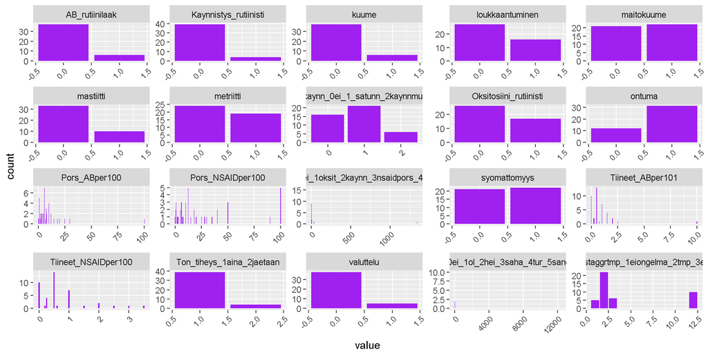

```r
gather(kuvat4) %>% ggplot(aes(value)) + facet_wrap("key", scales = "free") + geom_bar(fill="purple") + theme(axis.text.x = element_text(angle = 45, hjust = 1, size = 8))+   scale_fill_manual("key")
```

Sitten tarkastelen muuttujien nimia ja luonnetta (jatkuva/kategorinen).

```r
colnames(kuvat4)
```

```
##  [1] "Virike_0ei_1ol_2hei_3saha_4tur_5sanom_lelu"
##  [2] "Ton_tiheys_1aina_2jaetaan"
##  [3] "Yhdistaggrtmp_1eiongelma_2tmp_3eitmp"
##  [4] "Muutelkaynn_0ei_1_satunn_2kaynnmuusaann"
##  [5] "maitokuume"
##  [6] "metriitti"
##  [7] "valuttelu"
##  [8] "mastiitti"
##  [9] "ontuma"
## [10] "syomattomyys"
## [11] "kuume"
## [12] "loukkaantuminen"
## [13] "Tiineet_NSAIDper100"
## [14] "Tiineet_ABper101"
## [15] "Pors_NSAIDper100"
## [16] "Pors_ABper100"
## [17] "Rutiinilaak_0ei_1oksit_2kaynn_3nsaidpors_4kokkid_6ppab"
## [18] "AB_rutiinilaak"
## [19] "Oksitosiini_rutiinisti"
## [20] "Kaynnistys_rutiinisti"
```

```r
summary(kuvat4)
```

```
##  Virike_0ei_1ol_2hei_3saha_4tur_5sanom_lelu Ton_tiheys_1aina_2jaetaan
##  Min.   :    0.0                            Min.   :1.000
##  1st Qu.:    1.0                            1st Qu.:1.000
##  Median :    4.0                            Median :1.000
##  Mean   :  331.6                            Mean   :1.093
##  3rd Qu.:   14.0                            3rd Qu.:1.000
##  Max.   :12356.0                            Max.   :2.000
##  Yhdistaggrtmp_1eiongelma_2tmp_3eitmp
##  Min.   : 1.000
##  1st Qu.: 2.000
##  Median : 2.000
##  Mean   : 4.349
##  3rd Qu.: 3.000
##  Max.   :12.000
##  Muutelkaynn_0ei_1_satunn_2kaynnmuusaann   maitokuume       metriitti
##  Min.   :0.0000                          Min.   :0.0000   Min.   :0.0000
##  1st Qu.:0.0000                          1st Qu.:0.0000   1st Qu.:0.0000
##  Median :1.0000                          Median :1.0000   Median :0.0000
##  Mean   :0.7674                          Mean   :0.5116   Mean   :0.4419
##  3rd Qu.:1.0000                          3rd Qu.:1.0000   3rd Qu.:1.0000
##  Max.   :2.0000                          Max.   :1.0000   Max.   :1.0000
##    valuttelu        mastiitti          ontuma        syomattomyys
##  Min.   :0.0000   Min.   :0.0000   Min.   :0.0000   Min.   :0.0000
##  1st Qu.:0.0000   1st Qu.:0.0000   1st Qu.:0.0000   1st Qu.:0.0000
##  Median :0.0000   Median :0.0000   Median :1.0000   Median :1.0000
##  Mean   :0.1163   Mean   :0.2326   Mean   :0.7209   Mean   :0.5116
##  3rd Qu.:0.0000   3rd Qu.:0.0000   3rd Qu.:1.0000   3rd Qu.:1.0000
##  Max.   :1.0000   Max.   :1.0000   Max.   :1.0000   Max.   :1.0000
##      kuume        loukkaantuminen  Tiineet_NSAIDper100 Tiineet_ABper101
##  Min.   :0.0000   Min.   :0.0000   Min.   :0.0000      Min.   : 0.0000
##  1st Qu.:0.0000   1st Qu.:0.0000   1st Qu.:0.2250      1st Qu.: 0.2000
##  Median :0.0000   Median :0.0000   Median :0.5000      Median : 0.5000
##  Mean   :0.1395   Mean   :0.3721   Mean   :0.7047      Mean   : 0.8756
##  3rd Qu.:0.0000   3rd Qu.:1.0000   3rd Qu.:1.0000      3rd Qu.: 1.0000
##  Max.   :1.0000   Max.   :1.0000   Max.   :3.5000      Max.   :10.0000
##  Pors_NSAIDper100 Pors_ABper100
##  Min.   :  0.00   Min.   :  0.25
##  1st Qu.:  5.50   1st Qu.:  3.00
##  Median : 12.50   Median :  6.00
##  Mean   : 26.88   Mean   :  9.39
##  3rd Qu.: 37.50   3rd Qu.: 10.00
##  Max.   :100.00   Max.   :100.00
##  Rutiinilaak_0ei_1oksit_2kaynn_3nsaidpors_4kokkid_6ppab AB_rutiinilaak
##  Min.   :   0.00                                        Min.   :0.0000
##  1st Qu.:   0.00                                        1st Qu.:0.0000
##  Median :   1.00                                        Median :0.0000
##  Mean   :  35.95                                        Mean   :0.1395
##  3rd Qu.:   6.00                                        3rd Qu.:0.0000
##  Max.   :1346.00                                        Max.   :1.0000
##  Oksitosiini_rutiinisti Kaynnistys_rutiinisti
##  Min.   :0.0000         Min.   :0.00000
##  1st Qu.:0.0000         1st Qu.:0.00000
##  Median :0.0000         Median :0.00000
##  Mean   :0.3953         Mean   :0.09302
##  3rd Qu.:1.0000         3rd Qu.:0.00000
##  Max.   :1.0000         Max.   :1.00000
```

```r
#Pidetaan nama

keeps4<-
c(
"Virikeonei"
,"Ton_tiheys_1aina_2jaetaan"
,"Yhdistaggrtmp_1eiongelma_2tmp_3eitmp"
,"Muutelkaynn_0ei_1_satunn_2kaynnmuusaann"
,"maitokuume"
,"metriitti"
, "valuttelu"
,"mastiitti"
, "ontuma"
, "syomattomyys"
, "kuume"
, "loukkaantuminen"
, "Tiineet_NSAIDper100"
, "Tiineet_ABper101"
,"Pors_NSAIDper100"
, "Pors_ABper100"
, "AB_rutiinilaak"
, "Oksitosiini_rutiinisti"
, "Kaynnistys_rutiinisti")

kuvat4$Virikeonei<-ifelse(kuvat4$Virike_0ei_1ol_2hei_3saha_4tur_5sanom_lelu>0,1,0)

num4<-c("Tiineet_NSAIDper100"
, "Tiineet_ABper101"
,"Pors_NSAIDper100"
, "Pors_ABper100"                                         )

#kuvat1n<-kuvat1 %>%
#  select(num1)

#kuvat1<-kuvat1%>%
#  select(keeps1)

#Tama on kategoristen setti
kuvat41<- kuvat4 %>% dplyr::select(one_of(keeps4))%>%  dplyr::select(-one_of(num4))

#ja kategoriset muuttujat
kat4<-colnames(kuvat41)

#lisataan viela kuolleisuusjako
#kuvat1$EMKUOL<-tilat$EMKUOLLJAKO
#kuvat11<-drop(kuvat1,one_of(num1)
#%>%
#  rename(developer = assignee.login) %>%
#  select(-starts_with("assignee"), -title, -comments, -locked, #-labels, -id, -body) %>%
#  count(developer)
```

Paatan tiputtaa tassa kohtaa muutaman muuttujan. Lisaan aineistoon emkuoljako-muuttujan ja teen taulukon

```r
kuvat4$Muutelkaynn_0ei_1_satunn_2kaynnmuusaann<-ifelse(kuvat4$Muutelkaynn_0ei_1_satunn_2kaynnmuusaann>0,1,0)

df4<- dplyr::select(kuvat4, one_of(keeps4))
df4a<-df4
df4a$EMKUOL<-tilat$EMKUOLLJAKO


CreateTableOne(vars=keeps4,strata=c("EMKUOL"),factorVars=kat4,data=df4a)
```

```
##                                                  Stratified by EMKUOL
##                                                   0
##   n                                                  23
##   Virikeonei = 1 (%)                                 21 (91.3)
##   Ton_tiheys_1aina_2jaetaan = 2 (%)                   4 (17.4)
##   Yhdistaggrtmp_1eiongelma_2tmp_3eitmp (%)
##      1                                                4 (17.4)
##      2                                                9 (39.1)
##      3                                                4 (17.4)
##      12                                               6 (26.1)
##   Muutelkaynn_0ei_1_satunn_2kaynnmuusaann = 1 (%)    13 (56.5)
##   maitokuume = 1 (%)                                 12 (52.2)
##   metriitti = 1 (%)                                  10 (43.5)
##   valuttelu = 1 (%)                                   2 ( 8.7)
##   mastiitti = 1 (%)                                   4 (17.4)
##   ontuma = 1 (%)                                     15 (65.2)
##   syomattomyys = 1 (%)                               10 (43.5)
##   kuume = 1 (%)                                       2 ( 8.7)
##   loukkaantuminen = 1 (%)                            10 (43.5)
##   Tiineet_NSAIDper100 (mean (sd))                  0.82 (0.98)
##   Tiineet_ABper101 (mean (sd))                     0.72 (0.71)
##   Pors_NSAIDper100 (mean (sd))                    28.78 (35.04)
##   Pors_ABper100 (mean (sd))                       10.34 (19.96)
##   AB_rutiinilaak = 1 (%)                              2 ( 8.7)
##   Oksitosiini_rutiinisti = 1 (%)                      8 (34.8)
##   Kaynnistys_rutiinisti = 1 (%)                       0 ( 0.0)
##                                                  Stratified by EMKUOL
##                                                   1             p
##   n                                                  20
##   Virikeonei = 1 (%)                                 19 (95.0)   1.000
##   Ton_tiheys_1aina_2jaetaan = 2 (%)                   0 ( 0.0)   0.152
##   Yhdistaggrtmp_1eiongelma_2tmp_3eitmp (%)                       0.334
##      1                                                1 ( 5.0)
##      2                                               13 (65.0)
##      3                                                2 (10.0)
##      12                                               4 (20.0)
##   Muutelkaynn_0ei_1_satunn_2kaynnmuusaann = 1 (%)    14 (70.0)   0.551
##   maitokuume = 1 (%)                                 10 (50.0)   1.000
##   metriitti = 1 (%)                                   9 (45.0)   1.000
##   valuttelu = 1 (%)                                   3 (15.0)   0.868
```

[output cut: 23 more lines]

```
##   maitokuume = 1 (%)
##   metriitti = 1 (%)
##   valuttelu = 1 (%)
##   mastiitti = 1 (%)
##   ontuma = 1 (%)
##   syomattomyys = 1 (%)
##   kuume = 1 (%)
##   loukkaantuminen = 1 (%)
##   Tiineet_NSAIDper100 (mean (sd))
##   Tiineet_ABper101 (mean (sd))
##   Pors_NSAIDper100 (mean (sd))
##   Pors_ABper100 (mean (sd))
##   AB_rutiinilaak = 1 (%)
##   Oksitosiini_rutiinisti = 1 (%)
##   Kaynnistys_rutiinisti = 1 (%)
```

Tässä kohtaa vähän MCA-testailua, mutta muuttujia on valtavasti liikaa.

```r
dfall<-cbind(df1,df2,df3,df4)
dfall$EMKUOL<-tilat$EMKUOLLJAKO
dfall$Emakotcat<-ifelse(dfall$Emakot>400,1,0)
dfall$Ensikotcat<-ifelse(dfall$Ensikot>0,1,0)
dfall$Lihascat<-ifelse(dfall$Lihasiat_tontilla>0,1,0)
dfall$Porsab<-ifelse(dfall$Pors_ABper100>10,1,0)
dfall$PorsNSAIDS<-ifelse(dfall$Pors_NSAIDper100>12,1,0)
summary(as.numeric(dfall$Tiineet_ABper101))
```

```
##    Min. 1st Qu.  Median    Mean 3rd Qu.    Max.
##  0.0000  0.2000  0.5000  0.8756  1.0000 10.0000
```

```r
summary(as.numeric(dfall$Tiineet_NSAIDper100))
```

```
##    Min. 1st Qu.  Median    Mean 3rd Qu.    Max.
##  0.0000  0.2250  0.5000  0.7047  1.0000  3.5000
```

```r
dfall$TIINSAIDS<-ifelse(dfall$Tiineet_NSAIDper100>4,1,0)
dfall$TIIAB<-ifelse(dfall$Tiineet_ABper101>4,1,0)
summary(as.numeric(dfall$Pors_NSAIDper100))
```

```
##    Min. 1st Qu.  Median    Mean 3rd Qu.    Max.
##    0.00    5.50   12.50   26.88   37.50  100.00
```

```r
dfall<-dfall[ , !names(dfall) %in% c("Emakot","Ensikot","Karjut_haju","Lihasiat_tontilla","Pors_ABper100","Pors_NSAIDper100","Tiineet_ABper101","Tiineet_NSAIDper100")]
dfall<-dfall %>% mutate_all(as.factor)
tea_mca <- MCA(dfall, graph = FALSE)
summary(tea_mca)
```

```
##
## Call:
## MCA(X = dfall, graph = FALSE)
##
##
## Eigenvalues
##                        Dim.1   Dim.2   Dim.3   Dim.4   Dim.5   Dim.6
## Variance               0.110   0.075   0.063   0.063   0.058   0.053
## % of var.             10.321   7.072   5.926   5.882   5.427   4.971
## Cumulative % of var.  10.321  17.393  23.320  29.202  34.629  39.600
##                        Dim.7   Dim.8   Dim.9  Dim.10  Dim.11  Dim.12
## Variance               0.050   0.044   0.043   0.041   0.037   0.035
## % of var.              4.691   4.121   4.002   3.855   3.517   3.274
## Cumulative % of var.  44.291  48.412  52.414  56.269  59.786  63.060
##                       Dim.13  Dim.14  Dim.15  Dim.16  Dim.17  Dim.18
## Variance               0.030   0.029   0.027   0.026   0.025   0.024
## % of var.              2.834   2.682   2.574   2.433   2.317   2.215
## Cumulative % of var.  65.894  68.576  71.149  73.582  75.899  78.114
##                       Dim.19  Dim.20  Dim.21  Dim.22  Dim.23  Dim.24
## Variance               0.023   0.022   0.020   0.019   0.017   0.015
## % of var.              2.132   2.066   1.910   1.777   1.633   1.430
## Cumulative % of var.  80.246  82.312  84.223  86.000  87.633  89.063
##                       Dim.25  Dim.26  Dim.27  Dim.28  Dim.29  Dim.30
## Variance               0.014   0.013   0.012   0.011   0.010   0.008
## % of var.              1.305   1.263   1.127   1.010   0.973   0.792
## Cumulative % of var.  90.368  91.631  92.758  93.767  94.740  95.532
##                       Dim.31  Dim.32  Dim.33  Dim.34  Dim.35  Dim.36
## Variance               0.008   0.007   0.006   0.005   0.005   0.004
## % of var.              0.716   0.695   0.544   0.488   0.432   0.369
## Cumulative % of var.  96.248  96.944  97.488  97.976  98.408  98.777
##                       Dim.37  Dim.38  Dim.39  Dim.40  Dim.41  Dim.42
## Variance               0.004   0.003   0.002   0.002   0.001   0.001
## % of var.              0.349   0.269   0.213   0.176   0.133   0.085
## Cumulative % of var.  99.125  99.394  99.607  99.782  99.915 100.000
##
## Individuals (the 10 first)
##                                              Dim.1    ctr   cos2    Dim.2
## 1                                         |  0.519  5.700  0.205 | -0.201
## 2                                         | -0.312  2.064  0.084 | -0.479
## 3                                         | -0.227  1.092  0.065 | -0.098
```

[output cut: 62 more lines]

```
## Tautsuok_1                                -0.214  0.583  0.044 -1.358 |
## Tautsu_012_0                               0.000  0.000  0.000  0.000 |
##
## Categorical variables (eta2)
##                                             Dim.1 Dim.2 Dim.3
## Haastrooli_1OmEiosall_2OmOsall_3Esimies   | 0.163 0.342 0.133 |
## Tuotsuunta                                | 0.112 0.180 0.040 |
## Tautsu                                    | 0.508 0.003 0.000 |
## Tautsuok                                  | 0.335 0.006 0.044 |
## Tautsu_012                                | 0.537 0.028 0.051 |
## Siilotkat                                 | 0.048 0.000 0.052 |
## Tuhoei                                    | 0.078 0.038 0.075 |
## Eikulkuih                                 | 0.025 0.005 0.159 |
## Eikulkuel                                 | 0.004 0.041 0.010 |
## Suojvarpuh                                | 0.043 0.027 0.047 |
```

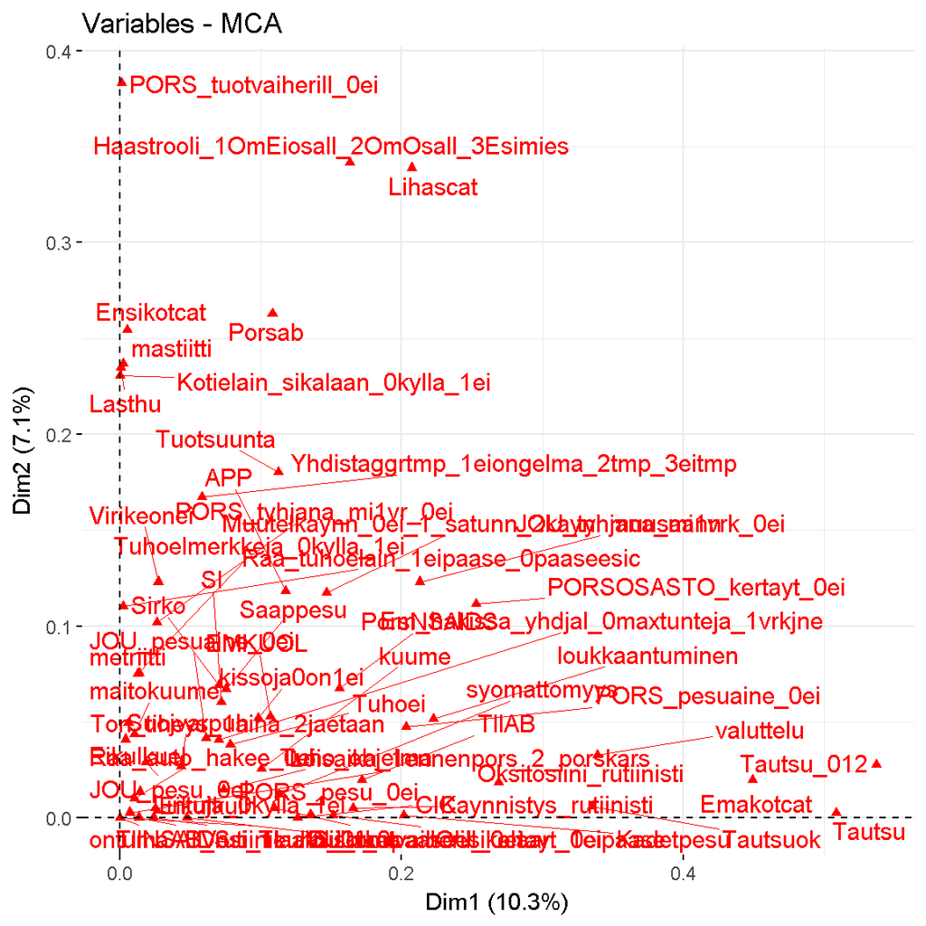

```r
fviz_mca_var(tea_mca, choice = "mca.cor",
            repel = TRUE, # Avoid text overlapping (slow)
            ggtheme = theme_minimal())
```

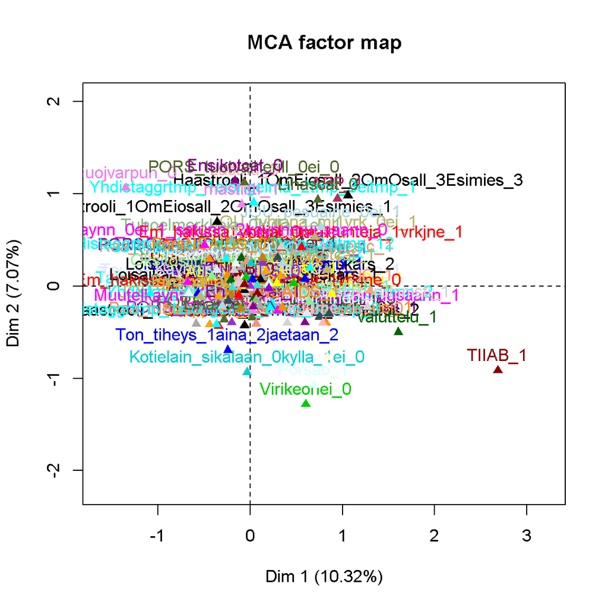

```r
plot(tea_mca, invisible=c("ind"), habillage = "quali")
```